# Survival - Final Project

David Coomes

February 26, 2020

## **Question 1**

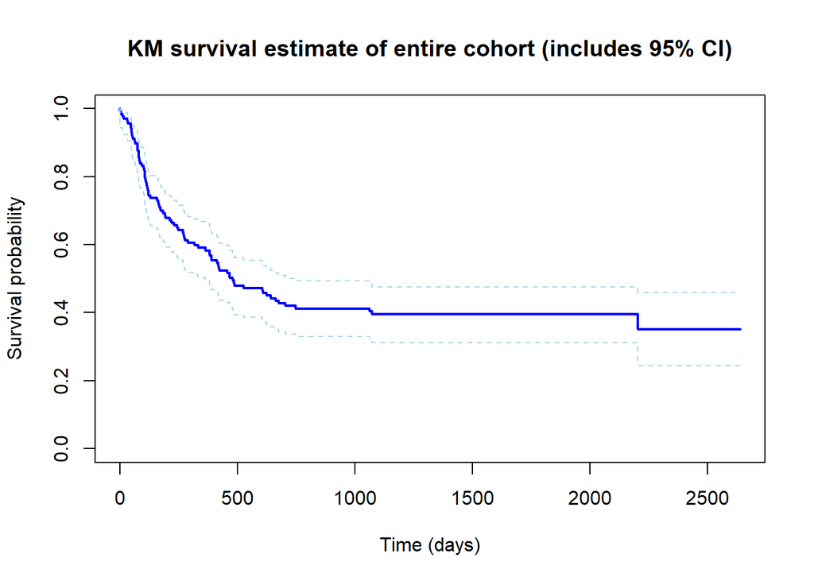

There were 137 individuals in the cohort. During the study period, 83 (61%) of them had the event of interest (relapse or death). The median survival time in this cohort was 481 days (95% CI: 363-748).

## **Question 3:**

We’re interested in finding the association of any of the baseline factors with the outcome:

- patient age (age: years)
- patient gender (male: 1=male, 0=female)
- donor age (donorage: years)
- donor gender (donormale: 1=male, 0=female)
- patient CMV status (cmv: 1=CMV positive, 0=CMV negative)
- donor CMV status (donorcmv: 1=CMV+, 0=CMV-)
- wait time from diagnosis to transplant (waittime: waiting time until transplant (in days))
- disease group (disgroup: 1=ALL, 2=AML low risk, 3=AML high risk)
- FAB classification (fab: 1=FAB grade 4 or 5 and AML, 0=otherwise)
- prophylactic use of methotrexate to prevent aGVHD (mtx: 1=Yes, 0=No)

**Table 1: Baseline factor association with survival using a univariate model**

Cox PH HR using univariate model

|  | HR | 95% CI lower | 95% CI upper | p value |
| --- | --- | --- | --- | --- |
| age | 1.011 | 0.988 | 1.035 | 0.338 |
| male | 0.795 | 0.514 | 1.228 | 0.301 |
| donorage | 1.014 | 0.990 | 1.040 | 0.252 |
| donormale | 0.991 | 0.633 | 1.552 | 0.970 |
| cmv | 1.167 | 0.759 | 1.796 | 0.482 |
| donorcmv | 1.047 | 0.677 | 1.620 | 0.836 |
| waittime | 1.000 | 0.999 | 1.001 | 0.791 |
| disgroup | 1.285 | 0.950 | 1.738 | 0.104 |
| fab | 1.892 | 1.222 | 2.929 | 0.004 |
| mtx | 1.489 | 0.934 | 2.373 | 0.094 |

**Table 2: Baseline factor association with survival while adjusting for other baseline factors**

Cox PH HR using multivariate model

|  | HR | HR 95% CI low | HR 95% CI high | p value |
| --- | --- | --- | --- | --- |
| age | 0.992 | 0.955 | 1.031 | 0.696 |
| male | 0.921 | 0.575 | 1.475 | 0.732 |
| donorage | 1.016 | 0.981 | 1.053 | 0.373 |
| donormale | 1.027 | 0.642 | 1.643 | 0.912 |
| cmv | 0.971 | 0.598 | 1.577 | 0.906 |
| donorcmv | 1.037 | 0.647 | 1.662 | 0.880 |
| waittime | 1.000 | 0.999 | 1.001 | 0.864 |
| disgroup | 1.118 | 0.775 | 1.613 | 0.550 |
| fab | 1.850 | 1.121 | 3.051 | 0.016 |
| mtx | 1.554 | 0.948 | 2.547 | 0.080 |

Of the measured baseline variables, only the FAB classification is significantly associated with differences in disease free survival. This association is significant using a univariate Cox PH model with FAB as the independent variable (p=0.004) and it remains significant after adjusting for all other baseline characteristics in a multivariate Cox PH model (p=0.016).